# Econ 294 Final

Chenxi Zhang

March 16, 2016

## Part A. Weather

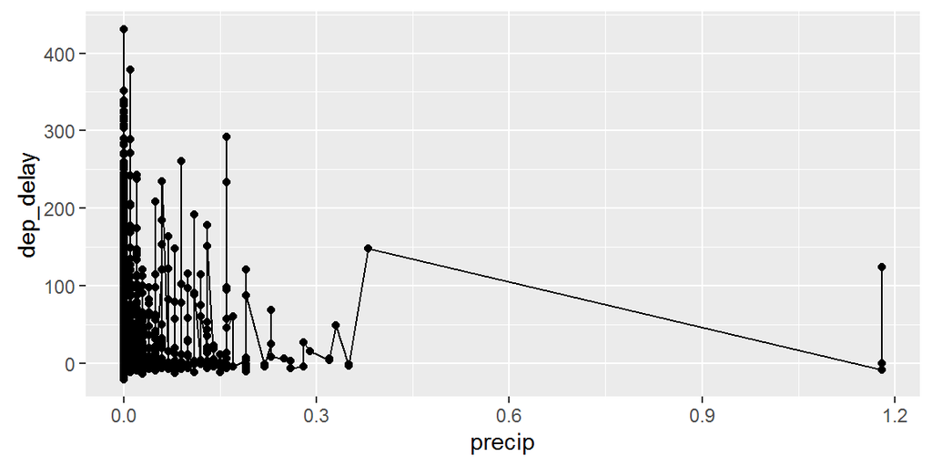

This plot explains the relationship between departure delays and precipitation.

**Weather**

|  | *Dependent variable:* |  |
| --- | --- | --- |
|  | dep_delay | canceled |
|  | (1) | (2) |
| temp | 0.189*** | 0.00004*** |
|  | (0.004) | (0.00000) |
| humid | -0.145*** | -0.00000 |
|  | (0.004) | (0.00000) |
| wind_speed | 0.028*** | 0.00000 |
|  | (0.004) | (0.00000) |
| precip | 49.282*** | -0.003 |
|  | (5.016) | (0.005) |
| pressure | -0.424*** | -0.00005*** |
|  | (0.011) | (0.00001) |
| visib | -2.089*** | -0.0002*** |
|  | (0.055) | (0.0001) |
| wind_dir | -0.005*** | -0.00000*** |
|  | (0.001) | (0.00000) |
| Constant | 461.473*** | 0.050*** |
|  | (10.911) | (0.010) |
| Observations | 281,563 | 281,563 |
| R<sup>2</sup> | 0.026 | 0.001 |
| Adjusted R<sup>2</sup> | 0.026 | 0.001 |
| Residual Std. Error (df = 281555) | 37.501 | 0.036 |
| F Statistic (df = 7; 281555) | 1,072.930*** | 25.486*** |
| *Note:* | p<0.1; p<0.05; p<0.01 |  |

The regression results exhibit the relationship between different weather conditions with delayed and cancelled flights.

Delay:

We can see that all of the weather condtions are statistically significant at the 99% level in determining delayed flights.

Cancel:

Meanwhile, there are 3 conditons play no signifcant role in a cancelled flight. It includes: humidity, wind speed and

precipitation. The other 4 conditions are statistically significant at the 99% level.

And we can also see that the effect of precipitation plays a most significant role on the delayed flights.

We can see that if we hold all else conditions constant, precipitation increases by 1 unit

depature delay will increase by 49.29 minetes.

## Part B Time

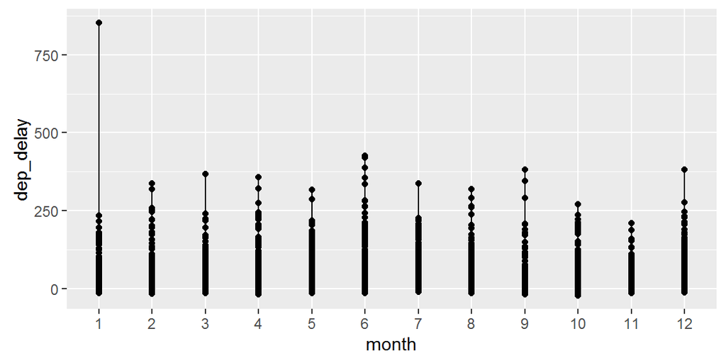

This plot explains the relationship between departure delays and time.

**time**

|  | *Dependent variable:* |  |
| --- | --- | --- |
|  | dep_delay | canceled |
|  | (1) | (2) |
| month2 | 0.765** | 0.001** |
|  | (0.344) | (0.0003) |
| month3 | 2.920*** | 0.0005 |
|  | (0.330) | (0.0003) |
| month4 | 3.772*** | 0.001*** |
|  | (0.331) | (0.0003) |
| month5 | 2.868*** | 0.001** |
|  | (0.329) | (0.0003) |
| month6 | 10.732*** | 0.002*** |
|  | (0.332) | (0.0003) |
| month7 | 11.557*** | 0.003*** |
|  | (0.329) | (0.0003) |
| month8 | 2.514*** | 0.0001 |
|  | (0.328) | (0.0003) |
| month9 | -3.028*** | 0.001*** |
|  | (0.333) | (0.0003) |
| month10 | -3.625*** | -0.0002 |
|  | (0.328) | (0.0003) |
| month11 | -4.532*** | 0.0002 |
|  | (0.333) | (0.0003) |
| month12 | 6.311*** | 0.001** |
|  | (0.333) | (0.0003) |
| day | -0.003 | -0.00001* |
|  | (0.008) | (0.00001) |
| hour | 2.141*** | 0.0001*** |
|  | (0.014) | (0.00001) |
| Constant | -18.071*** | -0.001* |
|  | (0.321) | (0.0003) |
| Observations | 328,521 | 328,521 |
| R<sup>2</sup> | 0.084 | 0.001 |
| Adjusted R<sup>2</sup> | 0.084 | 0.001 |
| Residual Std. Error (df = 328507) | 38.489 | 0.037 |
| F Statistic (df = 13; 328507) | 2,310.948*** | 18.741*** |
| *Note:* | p<0.1; p<0.05; p<0.01 |  |

The regression results exhibit the relationship between time with delayed and cancelled flights.

Delay:

In the result, January represents constant, all of the months and hour are statistically significant in determineing delayed flights.

Day is not statistically significant in determing delayed flights.

Cancel:

We can see that March, August, October,and November are not statistically significant in determing cancel.

Other months,day and hour are statistically significant in determing cancel.

## Part C airport destination

```
##
## Call:
## lm(formula = dep_delay ~ dest, data = a)
##
## Residuals:
##     Min      1Q  Median      3Q     Max
##  -58.16  -17.45  -13.22   -1.69 1291.71
##
## Coefficients:
##              Estimate Std. Error t value Pr(>|t|)
## (Intercept)  13.74016    2.51389   5.466 4.61e-08 ***
## destACK      -7.28355    3.51809  -2.070 0.038423 *
## destALB       9.88037    3.18600   3.101 0.001928 **
## destANC      -0.86516   14.38637  -0.060 0.952046
## destATL      -1.23033    2.53271  -0.486 0.627125
## destAUS      -0.71452    2.64263  -0.270 0.786867
## destAVL      -5.55004    3.52463  -1.575 0.115339
## destBDL       3.98072    3.19620   1.245 0.212966
## destBGR       5.73484    3.28306   1.747 0.080673 .
## destBHM      15.95470    3.49586   4.564 5.02e-06 ***
## destBNA       2.24231    2.56566   0.874 0.382134
## destBOS      -5.00954    2.53501  -1.976 0.048140 *
## destBQN      -1.35856    2.84977  -0.477 0.633556
## destBTV      -0.13451    2.63787  -0.051 0.959333
## destBUF      -0.31621    2.58271  -0.122 0.902557
## destBUR      -0.26448    3.26465  -0.081 0.935431
## destBWI       2.65666    2.69557   0.986 0.324347
## destBZN      -2.28301    7.22371  -0.316 0.751969
## destCAE      21.82994    4.61750   4.728 2.27e-06 ***
## destCAK       7.08072    2.86771   2.469 0.013545 *
## destCHO       7.65115    6.41989   1.192 0.233345
## destCHS       0.95462    2.62642   0.363 0.716256
## destCLE      -0.35223    2.58530  -0.136 0.891630
## destCLT      -4.51728    2.53709  -1.780 0.074995 .
## destCMH      -1.51637    2.60778  -0.581 0.560917
## destCRW       3.25984    4.24692   0.768 0.442738
## destCVG       5.78016    2.59785   2.225 0.026083 *
## destDAY       3.75842    2.73213   1.376 0.168936
## destDCA      -3.44716    2.54851  -1.353 0.176180
## destDEN       1.41607    2.55784   0.554 0.579839
```

[output cut: 66 more lines]

```
## destSTL       2.27040    2.58935   0.877 0.380584
## destSTT      -9.12626    3.06895  -2.974 0.002942 **
## destSYR       0.70461    2.69403   0.262 0.793672
## destTPA      -1.60515    2.55663  -0.628 0.530110
## destTUL      21.16620    3.41879   6.191 5.98e-10 ***
## destTVC       8.34318    4.80003   1.738 0.082185 .
## destTYS      14.75380    3.01529   4.893 9.94e-07 ***
## destXNA      -7.27527    2.81200  -2.587 0.009676 **
## ---
## Signif. codes:  0 '***' 0.001 '**' 0.01 '*' 0.05 '.' 0.1 ' ' 1
##
## Residual standard error: 40.06 on 328417 degrees of freedom
##   (8255 observations deleted due to missingness)
## Multiple R-squared:  0.007526,   Adjusted R-squared:  0.007214
## F-statistic: 24.18 on 103 and 328417 DF,  p-value: < 2.2e-16
```

```
##
## Call:
## lm(formula = canceled ~ dest, data = a)
##
## Residuals:
##      Min       1Q   Median       3Q      Max
## -0.12000 -0.03821 -0.02027 -0.00878  0.99730
##
## Coefficients:
##               Estimate Std. Error t value Pr(>|t|)
## (Intercept) -1.457e-14  9.896e-03   0.000 1.000000
## destACK     -7.397e-15  1.385e-02   0.000 1.000000
## destALB      4.784e-02  1.243e-02   3.847 0.000119 ***
## destANC      9.108e-15  5.663e-02   0.000 1.000000
## destATL      1.987e-02  9.969e-03   1.993 0.046277 *
## destAUS      9.020e-03  1.040e-02   0.867 0.385703
## destAVL      4.364e-02  1.373e-02   3.179 0.001477 **
## destBDL      6.998e-02  1.241e-02   5.637 1.73e-08 ***
## destBGR      4.533e-02  1.282e-02   3.537 0.000405 ***
## destBHM      9.428e-02  1.348e-02   6.994 2.67e-12 ***
## destBNA      3.821e-02  1.009e-02   3.786 0.000153 ***
## destBOS      3.095e-02  9.977e-03   3.102 0.001920 **
## destBQN      6.696e-03  1.121e-02   0.597 0.550312
## destBTV      2.974e-02  1.037e-02   2.868 0.004131 **
## destBUF      2.350e-02  1.016e-02   2.313 0.020740 *
## destBUR      2.695e-03  1.284e-02   0.210 0.833784
## destBWI      5.222e-02  1.058e-02   4.936 7.96e-07 ***
## destBZN      2.778e-02  2.809e-02   0.989 0.322672
## destCAE      8.621e-02  1.767e-02   4.878 1.07e-06 ***
## destCAK      2.546e-02  1.126e-02   2.262 0.023701 *
## destCHO      1.154e-01  2.401e-02   4.806 1.54e-06 ***
## destCHS      3.953e-02  1.032e-02   3.829 0.000129 ***
## destCLE      3.805e-02  1.017e-02   3.742 0.000182 ***
## destCLT      2.702e-02  9.985e-03   2.706 0.006810 **
## destCMH      5.590e-02  1.025e-02   5.456 4.88e-08 ***
## destCRW      2.899e-02  1.668e-02   1.738 0.082235 .
## destCVG      5.379e-02  1.021e-02   5.269 1.37e-07 ***
## destDAY      8.197e-02  1.069e-02   7.669 1.74e-14 ***
## destDCA      5.976e-02  1.002e-02   5.962 2.50e-09 ***
## destDEN      9.496e-03  1.007e-02   0.943 0.345548
```

[output cut: 66 more lines]

```
## destSRQ      7.432e-03  1.088e-02   0.683 0.494736
## destSTL      4.287e-02  1.018e-02   4.210 2.55e-05 ***
## destSTT      7.663e-03  1.207e-02   0.635 0.525372
## destSYR      2.953e-02  1.059e-02   2.789 0.005279 **
## destTPA      8.304e-03  1.006e-02   0.825 0.409238
## destTUL      5.714e-02  1.330e-02   4.296 1.74e-05 ***
## destTVC      5.941e-02  1.855e-02   3.202 0.001365 **
## destTYS      8.399e-02  1.172e-02   7.167 7.69e-13 ***
## destXNA      2.992e-02  1.104e-02   2.710 0.006734 **
## ---
## Signif. codes:  0 '***' 0.001 '**' 0.01 '*' 0.05 '.' 0.1 ' ' 1
##
## Residual standard error: 0.1577 on 336671 degrees of freedom
## Multiple R-squared:  0.01332,    Adjusted R-squared:  0.01301
## F-statistic:  43.7 on 104 and 336671 DF,  p-value: < 2.2e-16
```

The regression results exhibit the relationship between airport destinations with delayed and cancelled flights.

Delay:

These were all statistically significant at a level greater than 99%.

Cancel:

## Part D characteristics of the plane

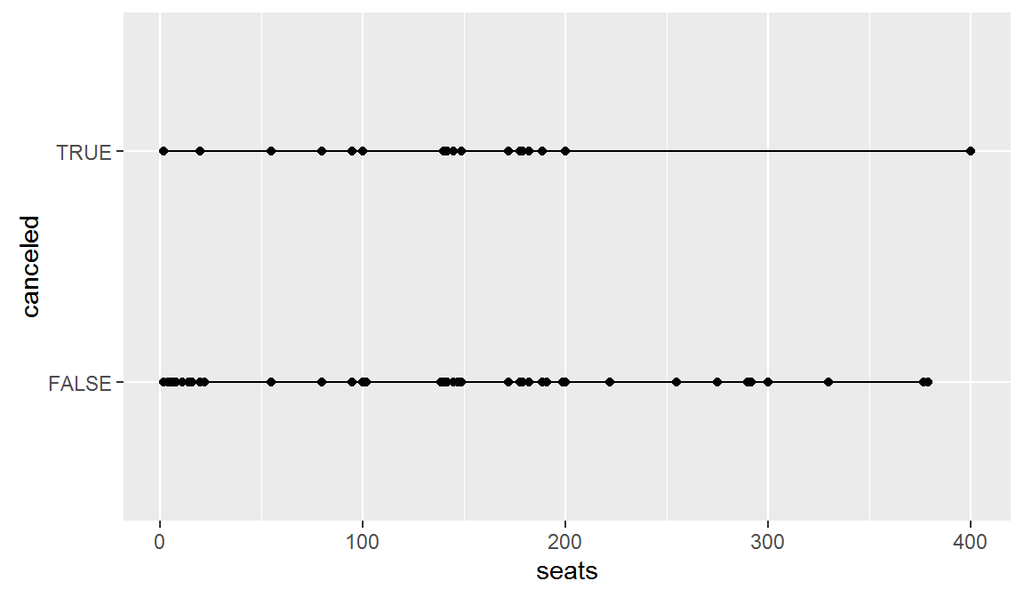

This plot explains the relationship between the number of seats and cancelled flights.

|  | *Dependent variable:* |  |
| --- | --- | --- |
|  | dep_delay | canceled |
|  | (1) | (2) |
| engines | -0.370 | 0.016*** |
|  | (1.428) | (0.004) |
| seats | -0.031*** | -0.0001*** |
|  | (0.001) | (0.00000) |
| engineReciprocating | -8.278 | 0.013 |
|  | (5.930) | (0.018) |
| engineTurbo-fan | -0.468 | -0.0002 |
|  | (6.022) | (0.019) |
| engineTurbo-jet | -2.024 | -0.008 |
|  | (6.028) | (0.019) |
| engineTurbo-prop | -3.746 | -0.015 |
|  | (8.480) | (0.026) |
| engineTurbo-shaft | -4.063 | -0.004 |
|  | (6.193) | (0.019) |
| Constant | 18.863*** | 0.005 |
|  | (6.019) | (0.019) |
| Observations | 279,971 | 284,170 |
| R<sup>2</sup> | 0.003 | 0.008 |
| Adjusted R<sup>2</sup> | 0.003 | 0.008 |
| Residual Std. Error | 40.510 (df = 279963) | 0.125 (df = 284162) |
| F Statistic | 135.281*** (df = 7; 279963) | 344.382*** (df = 7; 284162) |
| *Note:* | p<0.1; p<0.05; p<0.01 |  |

The regression results exhibit the relationship between characteristics of the plane with delayed and cancelled flights.

Delay:

Only the number of seats is statistically significant in determining delay. Other characteristics are not.

And the number of seats is statistically significant at a 99% level.

Cancel:

Only the number of seats and engines are statistically significant in determining cancelled flights. Other characteristics are not.

And the number of seats and engines are statistically significant at a 99% level.